# Be the boss of your factors

Dookyung Kim

2018-07-11

## Factors: where they fit in

Factors are the variable type that useRs love to hate. It is how we store truly categorical information in R.

- The values a factor can take on are called the **levels**.
  - “Africa”, “Americas”, etc.
  - human-readable character strings, like “male/female” and “control/treated”.
- R is really storing integer codes 1, 2, 3, etc.
- stealth factor: The variable that you think of as character, but that is actually a factor (numeric!!).
  - Base R has a burning desire to turn character information into factor.
  - To shut this down, use `stringsAsFactors = FALSE` in `read.table()` and `data.frame()` or – even better – **use the tidyverse**!

### The forcats package

forcats is a non-core package in the tidyverse. It is installed via `install.packages("tidyverse")`, but not loaded via `library(tidyverse)`. Load it yourself as needed via `library(forcats)`.

```
* Main functions start with `fct_`.
```

### Load tidyverse, forcats, gapminder

```r
library(tidyverse)
library(forcats)
library(gapminder)
```

### Factor inspection

```r
str(gapminder$continent)
```

```
#>  Factor w/ 5 levels "Africa","Americas",..: 3 3 3 3 3 3 3 3 3 3 ...
```

```r
levels(gapminder$continent)
```

```
#> [1] "Africa"   "Americas" "Asia"     "Europe"   "Oceania"
```

```r
nlevels(gapminder$continent)
```

```
#> [1] 5
```

```r
class(gapminder$continent)
```

```
#> [1] "factor"
```

To get a frequency table as a tibble, from a tibble, use `dplyr::count()`.

```
* To get similar from a free-range factor, use `forcats::fct_count()`.
```

```r
gapminder %>%
  count(continent)
```

```
#> # A tibble: 5 x 2
#>   continent     n
#>   <fct>     <int>
#> 1 Africa      624
#> 2 Americas    300
#> 3 Asia        396
#> 4 Europe      360
#> 5 Oceania      24
```

```r
fct_count(gapminder$continent)
```

```
#> # A tibble: 5 x 2
#>   f            n
#>   <fct>    <int>
#> 1 Africa     624
#> 2 Americas   300
#> 3 Asia       396
#> 4 Europe     360
#> 5 Oceania     24
```

### Dropping unused levels

drop all the rows corresponding to a specific factor level

Watch what happens to the levels of `country` (= nothing) when we filter Gapminder to a handful of countries.

```r
nlevels(gapminder$country)
```

```
#> [1] 142
```

```r
h_countries <- c("Egypt", "Haiti", "Romania", "Thailand", "Venezuela")
h_gap <- gapminder %>%
  filter(country %in% h_countries)
nlevels(h_gap$country)
```

```
#> [1] 142
```

Even though `h_gap` only has data for a handful of countries, we are still schlepping around all 142 levels from the original `gapminder` tibble.

How can you get rid of them?

```
* The base function `droplevels()` operates on all the factors in a data frame or on a single factor.

* The function `forcats::fct_drop()` operates on a factor.
```

```r
h_gap_dropped <- h_gap %>%
  droplevels()
nlevels(h_gap_dropped$country)
```

```
#> [1] 5
```

```r
## use forcats::fct_drop() on a free-range factor
h_gap$country %>%
  fct_drop() %>%
  levels()
```

```
#> [1] "Egypt"     "Haiti"     "Romania"   "Thailand"  "Venezuela"
```

Exercise: Filter the gapminder data down to rows where population is less than a quarter of a million, i.e. 250,000. Get rid of the unused factor levels for `country` and `continent` in different ways, such as:

- `droplevels()`
- `fct_drop()` inside `mutate()`
- `fct_dopr()` with `mutate_at()` or `mutate_if()`

### Change order of the levels, principled

By default, factor levels are ordered alphabetically.

How to order continent by frequency, esp. frequency barplots:

```r
## default order is alphabetical
gapminder$continent %>%
  levels()
```

```
#> [1] "Africa"   "Americas" "Asia"     "Europe"   "Oceania"
```

```r
## order by frequency
gapminder$continent %>%
  fct_infreq() %>%
  levels()
```

```
#> [1] "Africa"   "Asia"     "Europe"   "Americas" "Oceania"
```

```r
## backwards!
gapminder$continent %>%
  fct_infreq() %>%
  fct_rev() %>%
  levels()
```

```
#> [1] "Oceania"  "Americas" "Europe"   "Asia"     "Africa"
```

These two barcharts of frequency by continent differ only in the order of the continents. Which do you prefer?

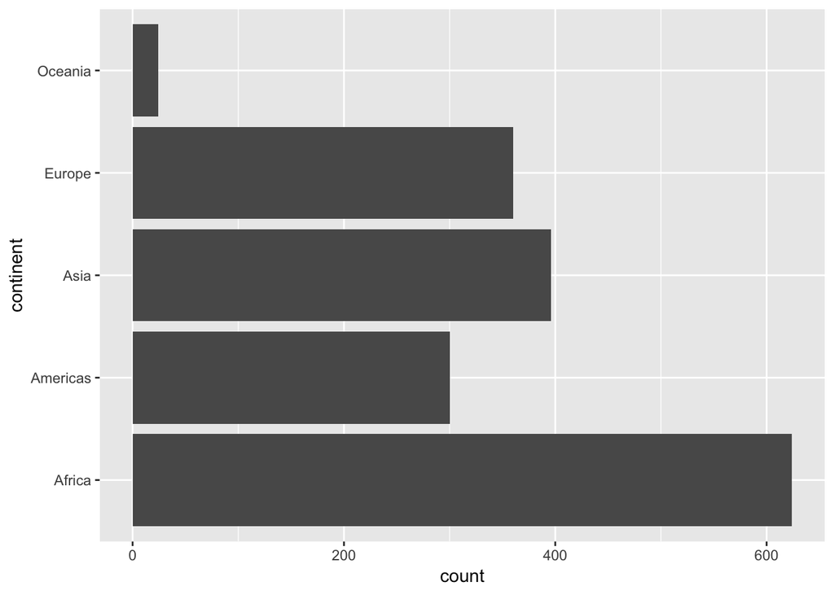

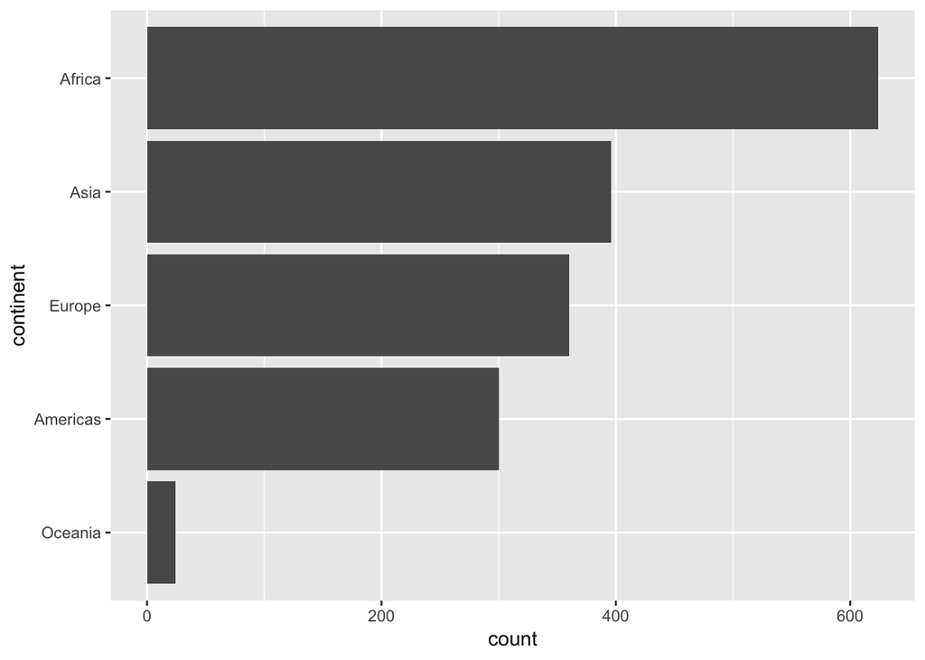

order `country` by another variable:

```r
## order countries by median life expectancy
fct_reorder(gapminder$country, gapminder$lifeExp) %>%
  levels() %>% head()
```

```
#> [1] "Sierra Leone"  "Guinea-Bissau" "Afghanistan"   "Angola"
#> [5] "Somalia"       "Guinea"
```

```r
## order accoring to minimum life exp instead of median
fct_reorder(gapminder$country, gapminder$lifeExp, min) %>%
  levels() %>% head()
```

```
#> [1] "Rwanda"       "Afghanistan"  "Gambia"       "Angola"
#> [5] "Sierra Leone" "Cambodia"
```

```r
## backwards!
fct_reorder(gapminder$country, gapminder$lifeExp, .desc = TRUE) %>%
  levels() %>% head()
```

```
#> [1] "Iceland"     "Japan"       "Sweden"      "Switzerland" "Netherlands"
#> [6] "Norway"
```

Example of why we reorder factor levels: often makes plots much better!

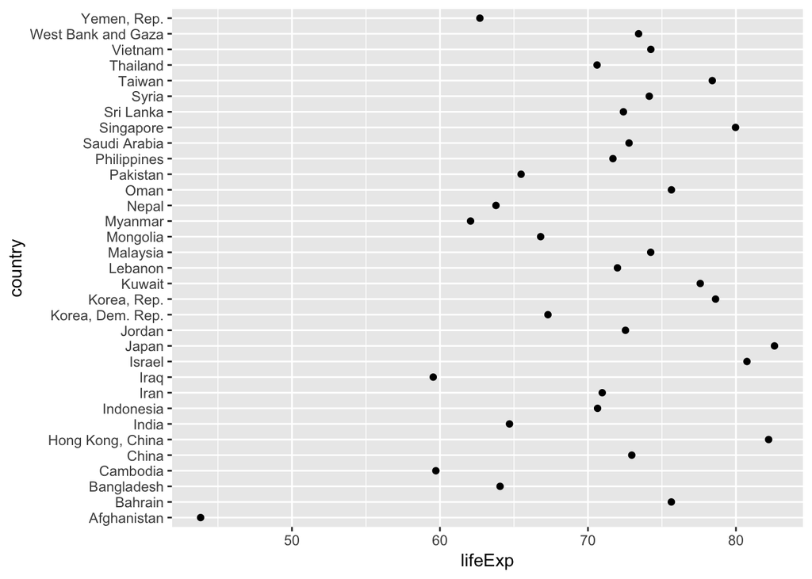

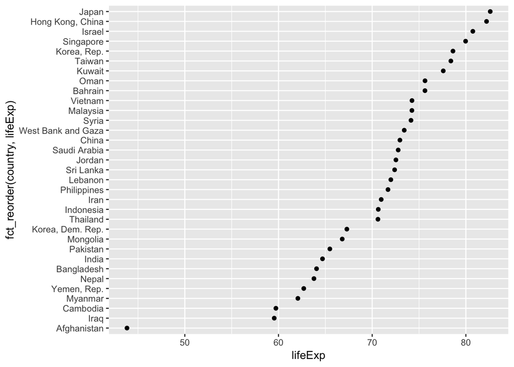

```r
gap_asia_2007 <- gapminder %>% filter(year == 2007, continent == "Asia")
ggplot(gap_asia_2007, aes(x = lifeExp, y = country)) + geom_point()
ggplot(gap_asia_2007, aes(x = lifeExp, y = fct_reorder(country, lifeExp))) +
  geom_point()
```

Use `fct_reorder2()` when you have a line chart of a quantitative x against another quantitative y and your factor provides the color.

```
* This way the legend appears in some order as the data!
```

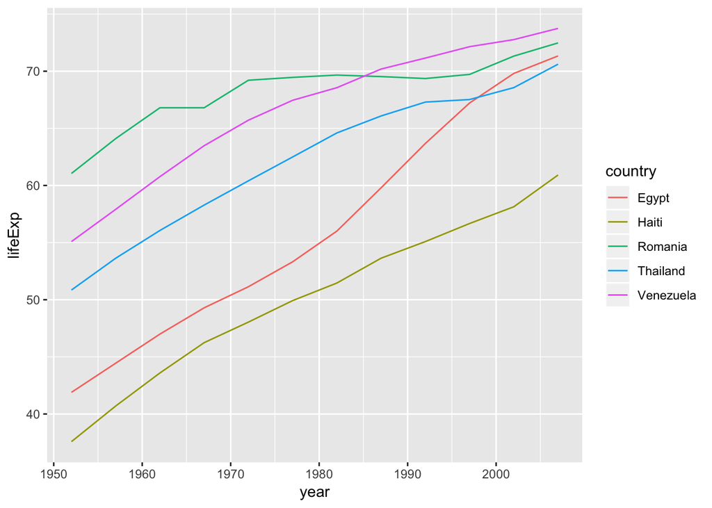

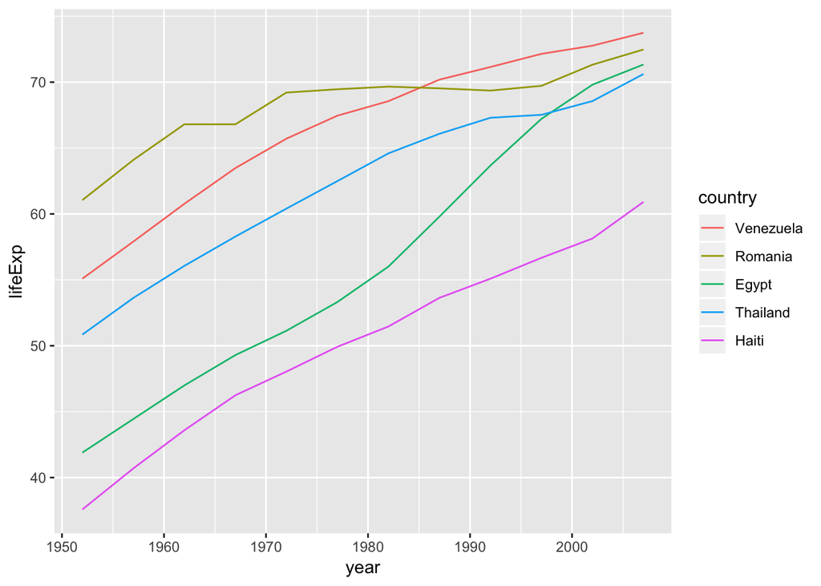

```r
h_countries <- c("Egypt", "Haiti", "Romania", "Thailand", "Venezuela")
h_gap <- gapminder %>%
  filter(country %in% h_countries) %>%
  droplevels()
ggplot(h_gap, aes(x = year, y = lifeExp, color = country)) +
  geom_line()
ggplot(h_gap, aes(x = year, y = lifeExp,
                  color = fct_reorder2(country, year, lifeExp))) +
  geom_line() +
  labs(color = "country")
```

### Change order of the levels, “because I said so”

This resembles what we do when we move variables to the front with `dplyr::select(special_var, everything())`.

```r
h_gap$country %>% levels()
```

```
#> [1] "Egypt"     "Haiti"     "Romania"   "Thailand"  "Venezuela"
```

```r
h_gap$country %>% fct_relevel("Romania", "Haiti") %>% levels()
```

```
#> [1] "Romania"   "Haiti"     "Egypt"     "Thailand"  "Venezuela"
```

### Recode the levels

Sometimes you have better ideas about what certain levels should be. This is called recoding.

```r
i_gap <- gapminder %>%
  filter(country %in% c("United States", "Sweden", "Australia")) %>%
  droplevels()

i_gap$country %>% levels()
```

```
#> [1] "Australia"     "Sweden"        "United States"
```

```r
i_gap$country %>%
  fct_recode("USA" = "United States", "Oz" = "Australia") %>% levels()
```

```
#> [1] "Oz"     "Sweden" "USA"
```

### Grow a factor

Let’s create two data frames, each with data from two countries, dropping unused factor levels.

```r
df1 <- gapminder %>%
  filter(country %in% c("United States", "Mexico"), year > 2000) %>%
  droplevels()
df2 <- gapminder %>%
  filter(country %in% c("France", "Germany"), year > 2000) %>%
  droplevels()
```

The `country` factors in `df1` and `df2` have different levels.

```r
levels(df1$country)
```

```
#> [1] "Mexico"        "United States"
```

```r
levels(df2$country)
```

```
#> [1] "France"  "Germany"
```

Can you just catenate them?

```r
c(df1$country, df2$country)
```

```
#> [1] 1 1 2 2 1 1 2 2
```

Umm, no. That is wrong on many levels! Use `fct_c()` to do this.

```r
fct_c(df1$country, df2$country)
```

```
#> [1] Mexico        Mexico        United States United States France
#> [6] France        Germany       Germany
#> Levels: Mexico United States France Germany
```

Exercise: Explore how different forms of row binding work behave here, in terms of the `country` variable in the result.

```r
bind_rows(df1, df2)


rbind(df1, df2)
```

```
#> # A tibble: 8 x 6
#>   country       continent  year lifeExp       pop gdpPercap
#>   <fct>         <fct>     <int>   <dbl>     <int>     <dbl>
#> 1 Mexico        Americas   2002    74.9 102479927    10742.
#> 2 Mexico        Americas   2007    76.2 108700891    11978.
#> 3 United States Americas   2002    77.3 287675526    39097.
#> 4 United States Americas   2007    78.2 301139947    42952.
#> 5 France        Europe     2002    79.6  59925035    28926.
#> 6 France        Europe     2007    80.7  61083916    30470.
#> 7 Germany       Europe     2002    78.7  82350671    30036.
#> 8 Germany       Europe     2007    79.4  82400996    32170.
```

### References

[stat545, Be the boss of your factors](http://stat545.com/block029_factors.html)